# FIESTA - Small Area Estimators

## Small Area (SA) module overview

`FIESTA`’s Small Area (SA) module was set up as a platform to integrate with current Small Area Estimators available on CRAN including the `JoSAE` (Breidenbach 2015), `sae` (Molina and Marhuenda 2015), and `hbsae` (Boonstra 2012) packages that use unit-level and area-level models such as the Empirical Best Linear Unbiased Prediction (EBLUP) estimation strategy and the hierarchical Bayesian estimation strategy. Rao (2003) discusses the benefits of the EBLUP for balancing potential bias of synthetic estimators against the instability of a direct estimator. White et al (2021) discusses the benefits of Small Area Estimation in a hierarchical Bayesian context, especially for forestry data. The module includes functional steps for checking, compiling, and formatting FIA plot data and auxiliary spatial information for input to R packages, such as `JoSAE` (Breidenbach 2015), `sae` (Molina and Marhuenda 2015), or `hbsae` (Boonstra 2012) and translates integrated package output to `FIESTA` output format.

Functions in `FIESTA` used for fitting Small Area Estimators include the `modSAarea` function for area estimates and `modSAtree` for tree estimates. The `modSApop` function is used to get population data needed for small area estimation. Below is a description and table of contents for the sections related to these functions:

| FUNCTION | DESCRIPTION |
| --- | --- |
| modSApop | Creates population data for small area estimation. |
| modSAarea | Produces area level estimates through small area estimation. |
| modSAtree | Produces tree level estimates through small area estimation. |

## Objective of tutorial

The main objective of this tutorial is to demonstrate how to use `FIESTA` for generating estimates using estimators from the `JoSAE`, `sae`, and `hbsae` R packages. The following examples are for generating estimates and estimated variances using standard FIA Evaluation data from FIA’s National database, with custom Estimation unit and Stratification information. The examples use data from three inventory years of field measurements in the state of Wyoming, from FIADB_1.7.2.00, last updated June 20, 2018, downloaded on June 25, 2018 and stored as internal data objects in FIESTA.

**View SA Example Data**

| Data Frame | Description |
| --- | --- |
| WYplt | WY plot-level data |
| WYcond | WY condition-level data |
| WYtree | WY tree-level data |

| External data | Description |
| --- | --- |
| WYbighorn_adminbnd.shp | Polygon shapefile of WY Bighorn National Forest Administrative boundary* |
| WYbighorn_districtbnd.shp | Polygon shapefile of WY Bighorn National Forest District boundaries** |
| WYbighorn_forest_nonforest_250m.tif | GeoTIFF raster of predicted forest/nonforest (1/0) for stratification*** |
| WYbighorn_dem_250m.img | Erdas Imagine raster of elevation change, in meters**** |

*USDA Forest Service, Automated Lands Program (ALP). 2018. S_USA.AdministrativeForest (). Description: An area encompassing all the National Forest System lands administered by an administrative unit. The area encompasses private lands, other governmental agency lands, and may contain National Forest System lands within the proclaimed boundaries of another administrative unit. All National Forest System lands fall within one and only one Administrative Forest Area.

**USDA Forest Service, Automated Lands Program (ALP). 2018. S_USA.RangerDistrict (http://data.fs.usda.gov/geodata/edw). Description: A depiction of the boundary that encompasses a Ranger District.

***Based on MODIS-based classified map resampled from 250m to 500m resolution and reclassified from 3 to 2 classes: 1:forest; 2:nonforest. Projected in Albers Conical Equal Area, Datum NAD27 (Ruefenacht et al. 2008). Clipped to extent of WYbighorn_adminbnd.shp.

****USGS National Elevation Dataset (NED), resampled from 30m resolution to 250m. Projected in Albers Conical Equal Area, Datum NAD27 (U.S. Geological Survey 2017). Clipped to boundary of WYbighorn_adminbnd.shp.

### Set up

First, you’ll need to load the `FIESTA` library:

```r
library(FIESTA)
```

Next, you’ll need to set up an “outfolder”. This is just a file path to a folder where you’d like `FIESTA` to send your data output. For our purposes in this vignette, we have saved our outfolder file path as the `outfolder` object in a temporary directory. We also set a few default options preferred for this vignette.

```r
outfolder <- tempdir()
```

### Get data for examples

**View Getting Data**

Now that we’ve loaded `FIESTA` and setup our outfolder, we can retrieve the data needed to run the examples. First, we point to some external data and predictor layers stored in `FIESTA` and derive new predictor layers using the `terra` package.

```r
# File names for external spatial data
WYbhfn <- system.file("extdata", "sp_data/WYbighorn_adminbnd.shp", package="FIESTA")
WYbhdistfn <- system.file("extdata", "sp_data/WYbighorn_districtbnd.shp", package="FIESTA")
WYbhdist.att <- "DISTRICTNA"

fornffn <- system.file("extdata", "sp_data/WYbighorn_forest_nonforest_250m.tif", package="FIESTA")
demfn <- system.file("extdata", "sp_data/WYbighorn_dem_250m.img", package="FIESTA")

# Derive new predictor layers from dem
library(terra)
dem <- rast(demfn)
slpfn <- paste0(outfolder, "/WYbh_slp.img")
slp <- terra::terrain(dem,
                      v = "slope",
                      unit = "degrees",
                      filename = slpfn,
                      overwrite = TRUE,
                      NAflag = -99999.0)
aspfn <- paste0(outfolder, "/WYbh_asp.img")
asp <- terra::terrain(dem,
                      v = "aspect",
                      unit = "degrees",
                      filename = aspfn,
                      overwrite = TRUE,
                      NAflag = -99999.0)
```

Next, we set up our small area domains with `FIESTA::spGetSAdoms`. For more information on how to use this function, please see the `sp` vignette included with `FIESTA` (link).

```r
smallbnd <- WYbhdistfn
smallbnd.domain <- "DISTRICTNA"
```

Next, we can get our FIA plot data and set up our auxiliary data. We can get our FIA plot data with the `spGetPlots` function from `FIESTA`, which accesses data through [FIA’s DataMart](https://apps.fs.usda.gov/fia/datamart/datamart.html). Here, data are downloaded for all states intersecting boundary, then subset to boundary.

```r
SApltdat <- spGetPlots(bnd = WYbhdistfn,
                       xy_datsource = "obj",
                       xy = WYplt,
                       xy_opts = list(xy.uniqueid = "CN", xvar = "LON_PUBLIC",
                                    yvar = "LAT_PUBLIC", xy.crs = 4269),
                       datsource = "obj",
                       istree = TRUE,
                       isseed = TRUE,
                       dbTabs = list(plot_layer = WYplt, cond_layer = WYcond,
                                   tree_layer = WYtree, seed_layer = WYseed),
                       eval = "custom",
                       eval_opts = list(invyrs = 2011:2013),
                       showsteps = TRUE,
                       returnxy = TRUE,
                       savedata_opts = savedata_options(outfolder = outfolder))
```

**output**

**plot**

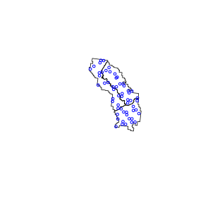

```r
str(SApltdat, max.level = 1)
```

**output**

```
## List of 11
##  $ spxy       :Classes 'sf' and 'data.frame':    56 obs. of  9 variables:
##   ..- attr(*, "sf_column")= chr "geometry"
##   ..- attr(*, "agr")= Factor w/ 3 levels "constant","aggregate",..: 3 3 3 3 3 3 3 3
##   .. ..- attr(*, "names")= chr [1:8] "PLT_CN" "INVYR" "STATECD" "UNITCD" ...
##  $ tabs       :List of 4
##  $ tabIDs     :List of 4
##  $ pltids     :'data.frame': 56 obs. of  8 variables:
##  $ bnd        :Classes 'sf' and 'data.frame':    3 obs. of  5 variables:
##   ..- attr(*, "sf_column")= chr "geometry"
##   ..- attr(*, "agr")= Factor w/ 3 levels "constant","aggregate",..: NA NA NA NA
##   .. ..- attr(*, "names")= chr [1:4] "REGION" "FORESTNUMB" "DISTRICTNU" "DISTRICTNA"
##  $ puniqueid  : chr "CN"
##  $ xy.uniqueid: chr "PLT_CN"
##  $ pjoinid    : chr "CN"
##  $ states     : chr "Wyoming"
##  $ invyrs     : int [1:3] 2011 2012 2013
##  $ args       :List of 13
```

Finally, we must generate the dataset with predictors for small area estimation. We can do this with the `spGetAuxiliary` function from `FIESTA`. Again, see the `sp` vignette for further information on this function.

```r
rastlst.cont <- c(demfn, slpfn, aspfn)
rastlst.cont.name <- c("dem", "slp", "asp")
rastlst.cat <- fornffn
rastlst.cat.name <- "fornf"

unit_layer <- WYbhdistfn
unitvar <- "DISTRICTNA"

auxdat <- spGetAuxiliary(
  xyplt = SApltdat$spxy,
  uniqueid = "PLT_CN",
  unit_layer = unit_layer,
  unitvar = "DISTRICTNA",
  rastlst.cont = rastlst.cont,
  rastlst.cont.name = rastlst.cont.name,
  rastlst.cont.stat = "mean",
  rastlst.cont.NODATA = 0,
  rastlst.cat = rastlst.cat,
  rastlst.cat.name = rastlst.cat.name,
  asptransform = TRUE,
  rast.asp = aspfn,
  keepNA = FALSE,
  showext = FALSE,
  savedata = FALSE
)
names(auxdat)
```

```r
str(auxdat, max.level = 1)
```

**output**

```
## List of 12
##  $ unitvar       : chr "DISTRICTNA"
##  $ pltassgn      :'data.frame':  56 obs. of  15 variables:
##  $ pltassgnid    : chr "PLT_CN"
##  $ unitarea      :'data.frame':  3 obs. of  2 variables:
##  $ areavar       : chr "ACRES_GIS"
##  $ unitzonal     :'data.frame':  3 obs. of  8 variables:
##  $ inputdf       :Classes 'data.table' and 'data.frame': 4 obs. of  7 variables:
##   ..- attr(*, ".internal.selfref")=<externalptr>
##  $ prednames     : chr [1:5] "dem" "slp" "asp_cos" "asp_sin" ...
##  $ zonalnames    : chr [1:7] "dem" "slp" "asp_cos" "asp_sin" ...
##  $ predfac       : chr "fornf"
##  $ npixelvar     : chr "npixels"
##  $ predfac.levels:List of 1
```

## Examples

### `modSApop`

#### Example 1: Creating our population dataset with `modMApop`

**View Example**

We can create our population data for model-assisted estimation. To do so, we use the `modSApop` function in `FIESTA`. We must assign our plot data with the `pltdat` argument, the auxiliary dataset with the `auxdat` argument, and set information for our small areas with the `smallbnd` and `smallbnd.domain` arguments. The `spGetPlots` and `spGetAuxiliary` functions have done much of the hard work for us so far, so we can just run a simple call to `modSApop`:

```r
SApopdat <- modSApop(pltdat = SApltdat,
                     auxdat = auxdat,
                     smallbnd = WYbhdistfn,
                         smallbnd.domain = smallbnd.domain)
```

Note that the `modSApop` function returns a list with lots of information and data for us to use. For a quick look at what this list includes we can use the `str` function:

```r
str(SApopdat, max.level = 1)
```

**output**

```
## List of 27
##  $ module         : chr "SA"
##  $ smallbnd       :Classes 'sf' and 'data.frame':    3 obs. of  6 variables:
##   ..- attr(*, "sf_column")= chr "geometry"
##   ..- attr(*, "agr")= Factor w/ 3 levels "constant","aggregate",..: NA NA NA NA NA
##   .. ..- attr(*, "names")= chr [1:5] "REGION" "FORESTNUMB" "DISTRICTNU" "DISTRICTNA" ...
##  $ smallbnd.domain: chr "DISTRICTNA"
##  $ condx          :Classes 'data.table' and 'data.frame':    66 obs. of  4 variables:
##   ..- attr(*, "sorted")= chr [1:2] "PLT_CN" "CONDID"
##   ..- attr(*, ".internal.selfref")=<externalptr>
##  $ pltcondx       :Classes 'data.table' and 'data.frame':    66 obs. of  30 variables:
##   ..- attr(*, ".internal.selfref")=<externalptr>
##   ..- attr(*, "sorted")= chr "DSTRBCD1"
##  $ pltassgnx      :Classes 'data.table' and 'data.frame':    56 obs. of  9 variables:
##   ..- attr(*, ".internal.selfref")=<externalptr>
##   ..- attr(*, "sorted")= chr "PLT_CN"
##  $ pltassgnid     : chr "PLT_CN"
##  $ cuniqueid      : chr "PLT_CN"
##  $ condid         : chr "CONDID"
##  $ ACI.filter     : chr "COND_STATUS_CD == 1"
##  $ dunitarea      :Classes 'data.table' and 'data.frame':    3 obs. of  2 variables:
##   ..- attr(*, ".internal.selfref")=<externalptr>
##   ..- attr(*, "sorted")= chr "DOMAIN"
##  $ areavar        : chr "ACRES_GIS"
##  $ areaunits      : chr "acres"
##  $ dunitvar       : chr "DOMAIN"
##  $ dunitlut       :Classes 'data.table' and 'data.frame':    3 obs. of  9 variables:
##   ..- attr(*, ".internal.selfref")=<externalptr>
##   ..- attr(*, "sorted")= chr "DOMAIN"
##  $ plotsampcnt    :'data.frame': 2 obs. of  3 variables:
##  $ condsampcnt    :'data.frame': 4 obs. of  3 variables:
##  $ states         : chr "Wyoming"
##  $ invyrs         :List of 1
##  $ estvar.area    : chr "CONDPROP_ADJ"
##  $ adj            : chr "plot"
##  $ treex          :'data.frame': 1691 obs. of  22 variables:
##  $ tuniqueid      : chr "PLT_CN"
##  $ adjtree        : logi FALSE
##  $ seedx          :'data.frame': 102 obs. of  11 variables:
##  $ prednames      : chr [1:5] "dem" "slp" "asp_cos" "asp_sin" ...
##  $ predfac        : chr "fornf"
```

Now that we’ve created our population dataset, we can move on to estimation.

### `modSAarea`

#### Example 2: Area of forest land, unit-level EBLUP

**View Example**

First, we can set up our predictors as a vector:

```r
all_preds <- c("slp", "dem", "asp_cos", "asp_sin", "fornf")
```

Next, we fit the unit-level EBLUP with the `JoSAE` R package.

```r
area1 <- modSAarea(
  SApopdatlst = SApopdat,        # pop - population calculations for WY, post-stratification
  prednames = all_preds,         # est - character vector of predictors to be used in the model
  SApackage = "JoSAE",           # est - character string of the R package to do the estimation
  SAmethod = "unit"              # est - method of small area estimation. Either "unit" or "area"
  )
```

**output**

```
## REML estimate of variance ratio: 0.09281
## numerical integration of f(x):   24.85 with absolute error < 7.9e-06
## numerical integration of x*f(x): 16.63 with absolute error < 8.2e-06
## posterior mean for variance ratio: 0.6693
```

**plot**

The `modSAarea` function outputs a list, and we can see our estimates and estimation method.

```r
str(area1, max.level = 1)
```

**output**

```
## List of 3
##  $ est    :Classes 'data.table' and 'data.frame':    3 obs. of  3 variables:
##   ..- attr(*, ".internal.selfref")=<externalptr>
##   ..- attr(*, "sorted")= chr "DOMAIN"
##  $ raw    :List of 13
##  $ multest:'data.frame': 3 obs. of  23 variables:
```

```r
area1$est
```

**output**

```
## Key: <DOMAIN>
##                            DOMAIN Estimate Percent Sampling Error
##                            <char>    <num>                  <num>
## 1: Medicine Wheel Ranger District 224320.1                  16.68
## 2:   Powder River Ranger District 149729.4                  26.23
## 3:         Tongue Ranger District 284851.4                  13.15
```

```r
area1$raw$SAmethod
```

**output**

```
## [1] "unit"
```

We can also look further into the `raw` list below:

```r
str(area1$raw, max.level = 1)
```

**output**

```
## List of 13
##  $ dunit_totest   :'data.frame': 3 obs. of  18 variables:
##  $ domdat         :'data.frame': 66 obs. of  15 variables:
##  $ module         : chr "SA"
##  $ esttype        : chr "AREA"
##  $ SApackage      : chr "JoSAE"
##  $ SAmethod       : chr "unit"
##  $ estnm          : chr "est"
##  $ predselect.unit:'data.frame': 1 obs. of  8 variables:
##  $ predselect.area:'data.frame': 1 obs. of  8 variables:
##  $ SAobjlst       :List of 1
##  $ estvar         : chr "AREA_ADJ"
##  $ areaunits      : chr "acres"
##  $ estunits       : chr "acres"
```

#### Example 3: Area of forest land, area-level EBLUP

**View Example**

In this example, we fit an area level EBLUP with `JoSAE`, while only using slp as a predictor. We use only one predictor in the area level model because at the area level, we only have three rows in our dataset. Since we also have a random effect term, the model we fit can have a maximum of one predictor without being exactly singular.

```r
area2 <- modSAarea(
  SApopdatlst = SApopdat,   # pop - population calculations for WY, post-stratification
  prednames = "slp",        # est - character vector of predictors to be used in the model
  SApackage = "JoSAE",      # est - character string of the R package to do the estimation
  SAmethod = "area",        # est - method of small area estimation. Either "unit" or "area"
  multest = TRUE
  )
```

**output**

```
## REML estimate of variance ratio: 0.09973
## numerical integration of f(x):   23.3 with absolute error < 1.1e-05
## numerical integration of x*f(x): 16.04 with absolute error < 7.3e-06
## posterior mean for variance ratio: 0.6883
```

**plot**

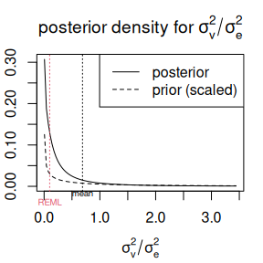

We again can see our estimates. Notably, we have slightly larger percent sampling errors to the unit-level model fit in Example 2. This is likely due to only being able to incorporate one predictor’s worth of information to the model.

```r
area2$est
```

**output**

```
## Key: <DOMAIN>
##                            DOMAIN Estimate Percent Sampling Error
##                            <char>    <num>                  <num>
## 1: Medicine Wheel Ranger District 246496.3                  19.80
## 2:   Powder River Ranger District 141310.9                  29.94
## 3:         Tongue Ranger District 295969.3                  14.01
```

Since `FIESTA` will attempt fit all models when running `modSAarea`, we can look at all the different modeling approaches and their estimates with the `multest` object.

```r
area2$multest
```

**output**

```
##                           DOMAIN LARGEBND NBRPLT       DIR     DIR.se  JU.Synth
## 1 Medicine Wheel Ranger District        1     16 0.6510417 0.11592491 0.6162340
## 2   Powder River Ranger District        1     19 0.3947368 0.11034865 0.5908995
## 3         Tongue Ranger District        1     21 0.7500000 0.09128709 0.6022887
##     JU.GREG JU.GREG.se  JU.EBLUP JU.EBLUP.se.1    hbsaeU  hbsaeU.se       JFH
## 1 0.6572931 0.11784552 0.6371466     0.1006813 0.6396496 0.10232397 0.6762099
## 2 0.4003265 0.11170013 0.4654312     0.1221846 0.4596133 0.10878798 0.4226600
## 3 0.7434288 0.08878553 0.6986757     0.1061928 0.7021458 0.09930096 0.7152836
##      JFH.se  JA.synth JA.synth.se      saeA   saeA.se hbsaeA hbsaeA.se
## 1 0.1339159 0.7295675   0.2534818 0.6762099 0.1339159     NA        NA
## 2 0.1265380 0.4879924   0.2458881 0.4226600 0.1265380     NA        NA
## 3 0.1001961 0.5965936   0.2044029 0.7152836 0.1001961     NA        NA
##   NBRPLT.gt0 AOI AREAUSED
## 1         11   1 364526.4
## 2          9   1 334337.0
## 3         17   1 413778.9
```

#### Example 4: Area of forest land, hierarchical Bayesian models

**View Example**

`FIESTA` also supports the use of hierarchical Bayesian (HB) models through the `hbsae` package as an alternative to EBLUPs. These models use the same model specification as the EBLUP, however they fit the model using a hierarchical Bayesian framework, and get parameter estimates through numerical integration. Luckily, we do not have to take an integral ourselves to fit these models, we can just change the `SApackage` argument.

```r
area3 <- modSAarea(
  SApopdatlst = SApopdat,   # pop - population calculations for WY, post-stratification
  prednames = all_preds,    # est - character vector of predictors to be used in the model
  SApackage = "hbsae",      # est - character string of the R package to do the estimation
  SAmethod = "unit",        # est - method of small area estimation. Either "unit" or "area"
  multest = TRUE
  )
```

**output**

```
## REML estimate of variance ratio: 0.09281
## numerical integration of f(x):   24.85 with absolute error < 7.9e-06
## numerical integration of x*f(x): 16.63 with absolute error < 8.2e-06
## posterior mean for variance ratio: 0.6693
```

**plot**

We can again check our estimates, small area method, and small area package.

```r
area3$est
```

**output**

```
## Key: <DOMAIN>
##                            DOMAIN Estimate Percent Sampling Error
##                            <char>    <num>                  <num>
## 1: Medicine Wheel Ranger District 226061.8                  16.01
## 2:   Powder River Ranger District 147433.8                  23.40
## 3:         Tongue Ranger District 285934.0                  12.89
```

```r
area3$raw$SAmethod
```

**output**

```
## [1] "unit"
```

```r
area3$raw$SApackage
```

**output**

```
## [1] "hbsae"
```

#### Example 5: Ara of forest land, hierarchical Bayesian models, changing prior distribution

**View Example**

Notably, we can also set priors on the ratio of between and within area variation with `hbsae`. By default, `FIESTA` uses a weakly informative half-Cauchy prior on this parameter as suggested by White et al (2021), but in this example we will fit the same model as before, but with a flat prior.

```r
area4 <- modSAarea(
  SApopdatlst = SApopdat,     # pop - population calculations for WY, post-stratification
  prednames = all_preds,      # est - character vector of predictors to be used in the model
  SApackage = "hbsae",        # est - character string of the R package to do the estimation
  SAmethod = "unit",          # est - method of small area estimation. Either "unit" or "area"
  prior = function(x) 1       # est - prior on ratio of between and within area variation
  )
```

**output**

[output not shown]

```r
area3$est
```

**output**

```
## Key: <DOMAIN>
##                            DOMAIN Estimate Percent Sampling Error
##                            <char>    <num>                  <num>
## 1: Medicine Wheel Ranger District 226061.8                  16.01
## 2:   Powder River Ranger District 147433.8                  23.40
## 3:         Tongue Ranger District 285934.0                  12.89
```

```r
area4$est
```

**output**

```
## Key: <DOMAIN>
##                            DOMAIN Estimate Percent Sampling Error
##                            <char>    <num>                  <num>
## 1: Medicine Wheel Ranger District       NA                     NA
## 2:   Powder River Ranger District       NA                     NA
## 3:         Tongue Ranger District       NA                     NA
```

#### Example 6: Area of forest land, with model variable selection, `JoSAE` unit level EBLUP

**View Example**

`FIESTA` supports model variable selection via the elastic net. To use model selection, we set the `modelselect` argument to `TRUE`.

```r
area5 <- modSAarea(
  SApopdatlst = SApopdat,      # pop - population calculations for WY, post-stratification
  prednames = all_preds,       # est - character vector of predictors to be used in the model
  SApackage = "JoSAE",         # est - character string of the R package to do the estimation
  SAmethod = "unit",           # est - method of small area estimation. Either "unit" or "area"
  modelselect = TRUE           # est - elastic net variable selection
  )
```

**output**

```
## REML estimate of variance ratio: 0.09281
## numerical integration of f(x):   24.85 with absolute error < 7.9e-06
## numerical integration of x*f(x): 16.63 with absolute error < 8.2e-06
## posterior mean for variance ratio: 0.6693
```

**plot**

We can now look at estimates with our subset of selected predictors and the predictors that were selected.

```r
area5$est
```

**output**

```
## Key: <DOMAIN>
##                            DOMAIN Estimate Percent Sampling Error
##                            <char>    <num>                  <num>
## 1: Medicine Wheel Ranger District 224320.1                  16.68
## 2:   Powder River Ranger District 149729.4                  26.23
## 3:         Tongue Ranger District 284851.4                  13.15
```

```r
area5$raw$predselect.unit
```

**output**

```
##   LARGEBND LARGEBND TOTAL         slp           dem    asp_cos     asp_sin
## 1 SApopdat        1     1 0.004745915 -0.0001050103 0.03462268 -0.06178897
##       fornf2
## 1 -0.3936355
```

### `modSAtree`

We will set our estimate variable and filter now. We set `estvar` to `"VOLCFNET"` for net cubic foot volume, and filter with `estvar.filter` set to `"STATUSCD == 1"` so we only consider live trees in our estimation.

```r
estvar <- "VOLCFNET"
live_trees <- "STATUSCD == 1"
```

**View Example**

```r
tree1 <- modSAtree(
    SApopdatlst = SApopdat,      # pop - population calculations for WY, post-stratification
    prednames = all_preds,       # est - character vector of predictors to be used in the model
    SApackage = "JoSAE",         # est - character string of the R package to do the estimation
    SAmethod = "unit",           # est - method of small area estimation. Either "unit" or "area"
    landarea = "FOREST",         # est - forest land filter
    estvar = estvar,             # est - net cubic-foot volume
    estvar.filter = live_trees   # est - live trees only
    )
```

**output**

```
## REML estimate of variance ratio: 0.01551
## numerical integration of f(x):   48.34 with absolute error < 2.6e-05
## numerical integration of x*f(x): 20.58 with absolute error < 1.3e-06
## posterior mean for variance ratio: 0.4257
```

**plot**

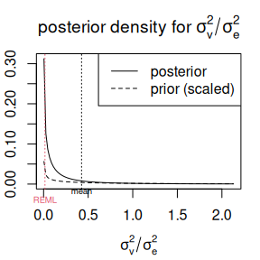

With both `modSAtree` and `modSAarea`, `FIESTA` will return your requested estimates specified with the `SApackage` and `SAmethod` arguments in the `est` item, but will return all possible estimates in the `multest` item. We can see these estimates below:

```r
tree1$est
```

**output**

```
## Key: <DOMAIN>
##                            DOMAIN  Estimate Percent Sampling Error
##                            <char>     <num>                  <num>
## 1: Medicine Wheel Ranger District 363533828                  24.03
## 2:   Powder River Ranger District 340071161                  36.20
## 3:         Tongue Ranger District 445171134                  25.10
```

```r
tree1$multest
```

**output**

```
##                           DOMAIN LARGEBND NBRPLT       DIR   DIR.se  JU.Synth
## 1 Medicine Wheel Ranger District        1     16 1175.1682 356.2906  967.9523
## 2   Powder River Ranger District        1     19  893.9355 315.0740 1090.1786
## 3         Tongue Ranger District        1     21 1340.8077 262.0320 1035.6947
##     JU.GREG JU.GREG.se  JU.EBLUP JU.EBLUP.se.1    hbsaeU hbsaeU.se JFH JFH.se
## 1 1122.3465   297.2844  997.2772      239.6662 1043.9097  252.6630  NA     NA
## 2  761.5703   252.7649 1017.1510      368.2101  907.4927  260.3908  NA     NA
## 3 1215.3733   240.0583 1075.8671      270.0696 1134.7262  236.6279  NA     NA
##   JA.synth JA.synth.se     saeA  saeA.se hbsaeA hbsaeA.se NBRPLT.gt0 AOI
## 1       NA          NA 1057.755 353.8882     NA        NA         10   1
## 2       NA          NA  963.751 419.8500     NA        NA          8   1
## 3       NA          NA 1356.026 471.4950     NA        NA         16   1
##   AREAUSED
## 1 364526.4
## 2 334337.0
## 3 413778.9
```

**View Example**

We can bring the `modelselect` parameter into play with `modSAtree` as well as `modSAarea`. In the below code, we set `modelselect = TRUE` to use the elastic net variable selection before fitting the model.

```r
tree2 <- modSAtree(
    SApopdatlst = SApopdat,      # pop - population calculations for WY, post-stratification
    prednames = all_preds,       # est - character vector of predictors to be used in the model
    SApackage = "JoSAE",         # est - character string of the R package to do the estimation
    SAmethod = "unit",           # est - method of small area estimation. Either "unit" or "area"
    landarea = "FOREST",         # est - forest land filter
    estvar = estvar,             # est - net cubic-foot volume
    estvar.filter = live_trees,   # est - live trees only
    modelselect = TRUE
    )
```

**output**

```
## REML estimate of variance ratio: 0.01633
## numerical integration of f(x):   47.54 with absolute error < 2e-05
## numerical integration of x*f(x): 20.28 with absolute error < 6.4e-06
## posterior mean for variance ratio: 0.4265
```

**plot**

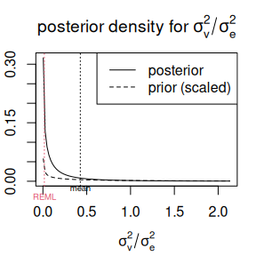

We now can look at the selected predictors and estimates.

```r
tree2$raw$predselect.unit
```

**output**

```
##   LARGEBND LARGEBND TOTAL       slp      dem asp_cos   asp_sin   fornf2
## 1 SApopdat        1     1 -63.70287 0.558082       0 -549.9468 -1176.35
```

```r
tree2$est
```

**output**

```
## Key: <DOMAIN>
##                            DOMAIN  Estimate Percent Sampling Error
##                            <char>     <num>                  <num>
## 1: Medicine Wheel Ranger District 363864644                  23.85
## 2:   Powder River Ranger District 338811410                  35.84
## 3:         Tongue Ranger District 446043897                  24.74
```

**View Example**

We can also use different response variables to estimate, and in this example we chose basal area. We also returned titles by using `returntitle = TRUE`.

```r
tree3 <- modSAtree(
    SApopdatlst = SApopdat,      # pop - population calculations for WY, post-stratification
    prednames = all_preds,       # est - character vector of predictors to be used in the model
    SApackage = "JoSAE",         # est - character string of the R package to do the estimation
    SAmethod = "unit",           # est - method of small area estimation. Either "unit" or "area"
    landarea = "FOREST",         # est - forest land filter
    estvar = "BA",               # est - net cubic-foot volume
    estvar.filter = live_trees,  # est - live trees only
    returntitle = TRUE
    )
```

**output**

```
## REML estimate of variance ratio: 0.03877
## numerical integration of f(x):   21.9 with absolute error < 8.2e-06
## numerical integration of x*f(x): 10.85 with absolute error < 4.8e-06
## posterior mean for variance ratio: 0.4955
```

**plot**

Now we can take a look at our estimates:

```r
tree3$est
```

**output**

```
## Key: <DOMAIN>
##                            DOMAIN Estimate Percent Sampling Error
##                            <char>    <num>                  <num>
## 1: Medicine Wheel Ranger District 22043124                  21.61
## 2:   Powder River Ranger District 18865170                  32.06
## 3:         Tongue Ranger District 29693976                  19.54
```

and see our title list since we set `returntitle` to `TRUE`.

```r
tree3$titlelst
```

**output**

```
## $title.estpse
## [1] "Basal area of live trees (at least 1 inch dia), in square feet, and percent sampling error on forest land DOMAIN"
##
## $title.yvar
## [1] "Basal area, in square feet"
##
## $title.estvar
## [1] "Basal area of live trees (at least 1 inch dia)"
##
## $title.unitvar
## [1] "DOMAIN"
##
## $title.ref
## [1] "Wyoming, 2011-2013"
##
## $outfn.estpse
## [1] "tree_BA_forestland"
##
## $outfn.rawdat
## [1] "tree_BA_forestland_rawdata"
##
## $title.tot
## [1] "Basal area of live trees (at least 1 inch dia), in square feet, on forest land; Wyoming, 2011-2013"
##
## $title.unitsn
## [1] "square feet"
```

**View Example**

Now, we can of course fit a different model to estimate basal area. In this case, we choose to use dem to predict basal area with an area-level EBLUP from the `sae` package.

```r
tree4 <- modSAtree(
    SApopdatlst = SApopdat,      # pop - population calculations for WY, post-stratification
    prednames = "dem",       # est - character vector of predictors to be used in the model
    SApackage = "sae",         # est - character string of the R package to do the estimation
    SAmethod = "area",           # est - method of small area estimation. Either "unit" or "area"
    landarea = "FOREST",         # est - forest land filter
    estvar = "BA",               # est - net cubic-foot volume
    estvar.filter = live_trees,  # est - live trees only
    returntitle = TRUE
    )
```

**output**

```
## REML estimate of variance ratio: 0.02124
## numerical integration of f(x):   24.4 with absolute error < 6e-06
## numerical integration of x*f(x): 10.37 with absolute error < 5.6e-06
## posterior mean for variance ratio: 0.4248
```

**plot**

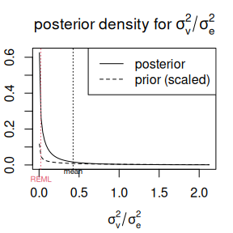

Now we can take a look at our estimates.

```r
tree4$est
```

**output**

```
## Key: <DOMAIN>
##                            DOMAIN Estimate Percent Sampling Error
##                            <char>    <num>                  <num>
## 1: Medicine Wheel Ranger District 22014434                  32.81
## 2:   Powder River Ranger District 17546600                  41.96
## 3:         Tongue Ranger District 35374035                  27.57
```

**View Example**

One may want to easily save `FIESTA` output to your computer, rather than just having it live in the R environment. `FIESTA` makes this easy with the use of the `savedata` and `savedata_opts` arguments. If `savedata = TRUE`, by default the output will be saved to your working directory, but we can set an `outfolder` in `savedata_opts` to choose where the data should be saved. There are many other `savedata_opts`, and these can be seen by looking at the help file for the `savedata_options` function (use `help(savedata_options)` with `FIESTA` loaded in your R environment).

```r
tree5 <- modSAtree(
    SApopdatlst = SApopdat,      # pop - population calculations for WY, post-stratification
    prednames = all_preds,       # est - character vector of predictors to be used in the model
    SApackage = "JoSAE",         # est - character string of the R package to do the estimation
    SAmethod = "unit",           # est - method of small area estimation. Either "unit" or "area"
    landarea = "FOREST",         # est - forest land filter
    estvar = "BA",               # est - net cubic-foot volume
    estvar.filter = live_trees,  # est - live trees only
    savedata = TRUE,
    savedata_opts = savedata_options(
      outfolder = outfolder
    )
    )
```

**output**

```
## REML estimate of variance ratio: 0.03877
## numerical integration of f(x):   21.9 with absolute error < 8.2e-06
## numerical integration of x*f(x): 10.85 with absolute error < 4.8e-06
## posterior mean for variance ratio: 0.4955
```

**plot**

**View Example**

We can also of course use a different model to predict basal area, and in this case we use a HB unit level model from `hbsae`. We also save to an outfolder again, this time giving a file name prefix with the `outfn.pre` arguement.

```r
tree6 <- modSAtree(
    SApopdatlst = SApopdat,      # pop - population calculations for WY, post-stratification
    prednames = all_preds,       # est - character vector of predictors to be used in the model
    SApackage = "hbsae",         # est - character string of the R package to do the estimation
    SAmethod = "unit",           # est - method of small area estimation. Either "unit" or "area"
    landarea = "FOREST",         # est - forest land filter
    estvar = "BA",               # est - net cubic-foot volume
    estvar.filter = live_trees,  # est - live trees only
    savedata = TRUE,
    savedata_opts = savedata_options(
      outfolder = outfolder,
      outfn.pre = "HB_unit"
    )
    )
```

**output**

```
## REML estimate of variance ratio: 0.03877
## numerical integration of f(x):   21.9 with absolute error < 8.2e-06
## numerical integration of x*f(x): 10.85 with absolute error < 4.8e-06
## posterior mean for variance ratio: 0.4955
```

**plot**

```r
list.files(outfolder, pattern = "HB")
```

**output**

```
## character(0)
```

And the estimates here:

```r
tree6$est
```

**output**

```
## Key: <DOMAIN>
##                            DOMAIN Estimate Percent Sampling Error
##                            <char>    <num>                  <num>
## 1: Medicine Wheel Ranger District 22549224                  21.66
## 2:   Powder River Ranger District 17699101                  26.52
## 3:         Tongue Ranger District 30499650                  17.10
```

## References

Molina I, Marhuenda Y. 2015. sae: An R Package for Small Area Estimation. The R Journal, 7(1), 81–98. https://journal.r-project.org/archive/2015/RJ-2015-007/RJ-2015-007.pdf.

Rao, J.N.K. 2003. Small Area Estimation. Wiley, Hoboken, New Jersey.